# Assignment 6

In this assignment, you'll analyze a collection of data sets from the [San Francisco Open Data Portal](http://data.sfgov.org/) and [Zillow](https://www.zillow.com/). The data sets have been stored in the SQLite database `sf_data.sqlite`, which you can [download here](http://anson.ucdavis.edu/~nulle/sf_data.sqlite). The database contains the following tables:

| Table | Description |
| --- | --- |
| `crime` | Crime reports dating back to 2010. |
| `mobile_food_locations` | List of all locations where mobile food vendors sell. |
| `mobile_food_permits` | List of all mobile food vendor permits. More details [here](https://data.sfgov.org/api/views/rqzj-sfat/files/8g2f5RV4PEk0_b24iJEtgEet9gnh_eA27GlqoOjjK4k?download=true&filename=DPW_DataDictionary_Mobil… |
| `mobile_food_schedule` | Schedules for mobile food vendors. |
| `noise` | Noise complaints dating back to August 2015. |
| `parking` | List of all parking lots. |
| `parks` | List of all parks. |
| `schools` | List of all schools. |
| `zillow` | Zillow rent and housing statistics dating back to 1996. More details [here](https://www.zillow.com/research/data/). |

The `mobile_food_` tables are explicitly connected through the `locationid` and `permit` columns. The other tables are not connected, but you may be able to connect them using dates, latitude/longitude, or postal codes.

Shapefiles for US postal codes are available [here](https://www.census.gov/geo/maps-data/data/cbf/cbf_zcta.html). These may be useful for converting latitude/longitude to postal codes.

Shapefiles for San Francisco Neighborhoods are available [here](https://data.sfgov.org/Geographic-Locations-and-Boundaries/SF-Find-Neighborhoods/pty2-tcw4).

**Exercise 1.1.** Which mobile food vendor(s) sells at the most locations?

[figure not shown]

```python
from mpl_toolkits.basemap import Basemap
import matplotlib.pyplot as plt
import scipy.stats as ss
import numpy as np
from matplotlib.patches import Circle, Wedge, Polygon
import pandas as pd
import sqlalchemy as sqla
import sqlite3 as sql
%matplotlib inline
import matplotlib.cm
from matplotlib.collections import PatchCollection
from matplotlib.colors import Normalize
from statsmodels.graphics.mosaicplot import mosaic
import geopandas as gpd
import shapely.geometry as geom
%matplotlib inline
fig, ax = plt.subplots(figsize=(10,20))
```

```python
db = sql.connect("sf_data.sqlite")
db.row_factory = sql.Row
cursor = db.execute("SELECT * FROM mobile_food_permits")
rows = cursor.fetchall()
cursor2 = db.execute("SELECT * FROM mobile_food_locations")
rows2 = cursor2.fetchall()
cursor3  = db.execute("SELECT * FROM mobile_food_schedule")
rows3 = cursor3.fetchall()
curse4 = db.execute("SELECT * FROM mobile_food_schedule INNER JOIN mobile_food_locations ON mobile_food_schedule.locationid = mobile_food_locations.locationid INNER JOIN mobile_food_permits ON mobile_food_schedule.permit = mobile_food_permits.permit")
rowing = curse4.fetchall()
print rowing[0].keys()
```

```
['locationid', 'permit', 'DayOfWeek', 'EndHour', 'StartHour', 'locationid', 'LocationDescription', 'Address', 'Latitude', 'Longitude', 'permit', 'Status', 'Applicant', 'FacilityType', 'FoodItems', 'PriorPermit', 'Approved', 'Expiration']
```

```python
ourdfsql = pd.read_sql("SELECT * FROM mobile_food_schedule INNER JOIN mobile_food_locations ON mobile_food_schedule.locationid = mobile_food_locations.locationid INNER JOIN mobile_food_permits ON mobile_food_schedule.permit = mobile_food_permits.permit",db)
ourdfsql = ourdfsql.iloc[:,1:]
```

```python
from collections import Counter
listing = ourdfsql['Applicant']
dictlist = Counter(listing)
orderedlist = dictlist.most_common()
orderedlist[:5]
```

```
[(u'May Catering', 340),
 (u"Natan's Catering", 221),
 (u'Anas Goodies Catering', 212),
 (u'Liang Bai Ping', 182),
 (u'Mang Hang Catering', 165)]
```

**Exercise 1.2.** Ask and use the database to analyze 5 questions about San Francisco. For each question, write at least 150 words and support your answer with plots. Make a map for at least 2 of the 5 questions.

You should try to come up with some questions on your own, but these are examples of reasonable questions:

- Which parts of the city are the most and least expensive?
- Which parts of the city are the most dangerous (and at what times)?
- Are noise complaints and mobile food vendors related?
- What are the best times and places to find food trucks?
- Is there a relationship between housing prices and any of the other tables?

Please make sure to clearly state each of your questions in your submission.

## Question 1

### Where is the Most Expensive Place to Live

```python
db = sql.connect("sf_data.sqlite")
db.row_factory = sql.Row
zillowrent = pd.read_sql("SELECT * FROM zillow",db)

db.close()
```

```python
price = zillowrent[np.isfinite(zillowrent['MedianSoldPricePerSqft_AllHomes'])]
zipandprice = price.groupby('RegionName')['MedianSoldPricePerSqft_AllHomes'].apply(list)
means = []
region = zipandprice.index
for i in zipandprice:
    a = sum(i)/len(i)
    means.append(a)
region = list(region)
mean = pd.DataFrame(means,columns = ['price'])
zips = pd.DataFrame(region,columns = ['Zip'])
findf = zips.join(mean)
```

```python
zipcodes = gpd.read_file("cb_2015_us_zcta510_500k.shp")
```

```python
alist = findf['Zip']
zipscal = zipcodes[zipcodes.ZCTA5CE10.str.startswith("9")]
zipscali = zipscal[pd.to_numeric(zipscal['ZCTA5CE10']) <= 97000]
zipscali['ZCTA5CE10'] = pd.to_numeric(zipscali['ZCTA5CE10'])
```

```python
dfs = zipscali[zipscali['ZCTA5CE10'].isin(alist)]
findf.columns = ['ZCTA5CE10','Price']
```

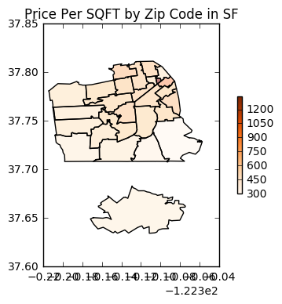

```python
plotdf = dfs.merge(findf, on = 'ZCTA5CE10')
norm = Normalize()
cmap = plt.get_cmap('Oranges')
mapper = matplotlib.cm.ScalarMappable(norm=norm, cmap=cmap)
mapper.set_array(plotdf['Price'])
plotdf.plot(column = 'Price',cmap = 'OrRd',axes = None)
plt.title("Price Per SQFT by Zip Code in SF")
plt.colorbar(mapper, shrink=0.4)
```

#### Analysis

Looking at the map of San Francisco, we can see that the most expensive area is near the financial district. At 1336 dollars per Sq Foot, the Financial District has the highest price per sq Foot by over 500 dollars per sq foot. We also see from the map that the north eastern side of San Francisco is more expensive than the rest of San Francisco. Most of the zip codes in San Francisco seem to have similar price per sq foot next to their neighboring zip codes. We see the more residential areas in the south western part of the peninsula have significantly lower price per sqft values than the north eastern part.

## Question 2:

### What is the most frequent crime type in San Francisco and on What Day?

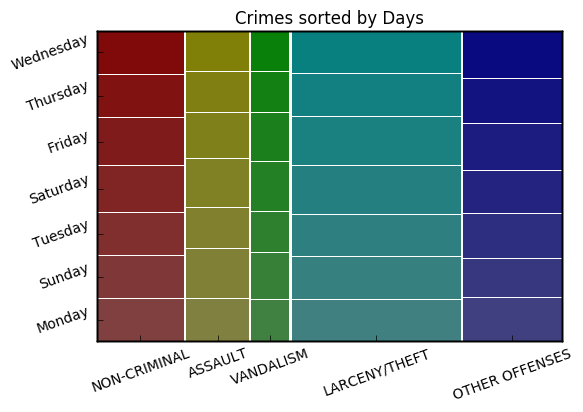

```python
db = sql.connect("sf_data.sqlite")
crime = db.execute("SELECT * FROM crime")
deathrow = crime.fetchall()

db.close()
sfcrime = pd.DataFrame(deathrow,columns = ['id','type','details','day','time','area','status','address','long','lat'])
crimcount = Counter(sfcrime['type'])
daycrime = Counter(sfcrime['day'])

crimcounts = pd.DataFrame(crimcount.items(),columns = ['type','count'])
days = pd.DataFrame(daycrime.items(),columns = ['day','count'])
crimdays = pd.DataFrame(crimcount.items(),columns = ['type','count'])
crimsort = crimcounts.sort(columns = 'count',ascending=False)
daysort = days.iloc[[0,1,3,4,2,6,5],:]
crimtopten = crimsort.iloc[:10,:]
crimtopten.set_index('type',inplace=True)
daycrime
crimtopfive = crimsort.iloc[:5,:]
crimtopfive.set_index('type',inplace=True)
crimfiv = []
for i in list(crimtopfive.index):
    crimfiv.append(str(i))
topfivedf = sfcrime[sfcrime['type'].isin(crimfiv)]
topfivedf.head()
yes = mosaic(topfivedf,['type','day'],labelizer= lambda k:'',properties = lambda k:'',label_rotation=20,title = 'Crimes sorted by Days')
```

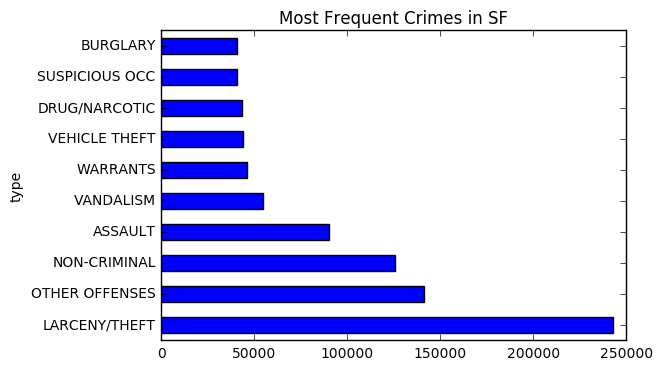

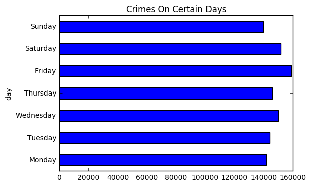

```python
type(crimcount)
crimcounts = pd.DataFrame(crimcount.items(),columns = ['type','count'])
days = pd.DataFrame(daycrime.items(),columns = ['day','count'])
crimdays = pd.DataFrame(crimcount.items(),columns = ['type','count'])
crimsort = crimcounts.sort(columns = 'count',ascending=False)
daysort = days.iloc[[0,1,3,4,2,6,5],:]
crimtopten = crimsort.iloc[:10,:]
crimtopten.set_index('type',inplace=True)
crimtopten.plot.barh(title = 'Most Frequent Crimes in SF',legend = None);
daysort.set_index('day',inplace=True)
daysort.plot.barh(title = 'Crimes On Certain Days',legend = None)
```

#### Analysis

From the plots above we clearly see that Larceny and Theft is the most frequent type of crime in San Francisco. It accounts for almost a quarter of all crimes in the city. We also see that Friday and Saturday are when Crimes most frequently occur. While one might suspect that because these two days are the weekend, more people would have free time and have a higher propensity to get drunk. There is no evidence of an increase in non-criminal or acoholic related crimes on weekends. For the most parts there is simply an uptick in crime on these days, though not significant. If we were to see the BAC levels and other drug levels for people arrested though, there may still be a correlation between people doing recreational drugs and then getting arrested for doing more serious crimes. However, since we do not have this data, all we can tell is there is no significant increase in the type of crimes and the day of the week.

### Question 3:

```
Do Parks help increase home values.
```

```python
db = sql.connect("sf_data.sqlite")
cursor = db.execute('SELECT * FROM parks')
parkrow = cursor.fetchall()
db.close()
```

```python
parkdf = pd.DataFrame(parkrow,columns = ['name','type','Acres','ID','lat','long'])
```

```python
import zipcode
parkdf.iloc[:2,-2:]
zipcode.isinradius((37.781844,-122.468099), 1)
parkdf.iloc[:2,-2:]
nolong = parkdf[np.isfinite(parkdf['long'])]
nolat = nolong[np.isfinite(nolong['lat'])]
ourparkzips = []
tups = []
def zipfinder():
    for i in range(len(nolat)):
        tups.append(tuple(nolat.iloc[i,-2:]))
    for j in range(len(tups)):
        ourparkzips.append(zipcode.isinradius(tups[j], 1))
    return ourparkzips
```

```python
tuple(parkdf.iloc[0,-2:])
```

```
(37.781843969999997, -122.46809908)
```

```python
ok = zipfinder()
```

```python
finalzip = [ok[i][:1] for i in range(len(ok))]
zipam = [str(finalzip[i][:1]) for i in range(len(ok)) ]
```

```python
firstpark = [zipam[i].replace('[<Zip:','') for i in range(len(zipam))]
secondpark = [firstpark[i].replace('>]','') for i in range(len(firstpark))]
thirdpark = []
for x in secondpark:
    try:
        thirdpark.append(int(x))
    except(ValueError):
        thirdpark.append(np.NAN)
```

```python
type(thirdpark[0])
```

```
int
```

```python
thirdparkdf = pd.DataFrame()
thirdparkdf['ZCTA5CE10'] = pd.Series(thirdpark,dtype = object)
```

```python
parkzipdf = nolat.join(thirdparkdf)
```

```python
finparkzipdf = parkzipdf[parkzipdf.ZCTA5CE10.notnull()]
ziplist = finparkzipdf['ZCTA5CE10']
zipcounts = Counter(ziplist)
zippkcount = zipcounts.most_common()
parkcountdata = pd.DataFrame(zippkcount,columns = ['ZCTA5CE10','count'])
```

[figure not shown]

```python
pricevpark = findf.merge(parkcountdata,on = 'ZCTA5CE10')
plotpricevpark = plotdf.merge(parkcountdata,on = 'ZCTA5CE10')
ploting = pricevpark.plot.scatter(x = 'ZCTA5CE10',y = 'Price',title = 'Price Per SqFt Versus number of Parks per Zip Code');
ploting.set_xlabel('Number of Parks Per Zip');
ploting.set_ylabel('Price Per SqFt');
```

[figure not shown]

```python
wollier = pricevpark[pricevpark['Price'] < 1000]
ploting = wollier.plot.scatter(x = 'ZCTA5CE10',y = 'Price',title = 'Price Per SqFt Versus number of Parks  W/O Outlier');
ploting.set_xlabel('Number of Parks Per Zip');
ploting.set_ylabel('Price Per SqFt');
```

#### Analysis

```python
lats = list(nolat.lat)
lons = list(nolat.long)
```

[output not shown]

[output cut: 147 more lines]

[output not shown]

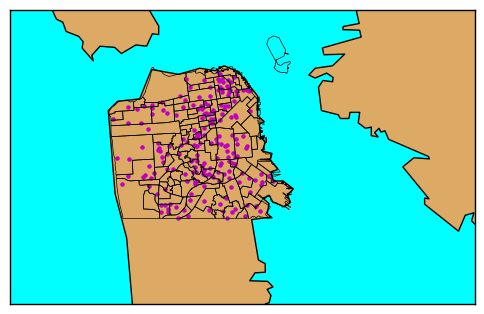

```python
sfigure = 'geo_export_74da5d7f-2883-4240-8d0d-f91d14b65588'


map = Basemap(llcrnrlon=-122.6, llcrnrlat=37.65, urcrnrlon=-122.2, urcrnrlat=37.85, resolution="h",
    projection="merc")

map.readshapefile(sfigure,'sfigure')
map.drawmapboundary(fill_color='aqua')
map.fillcontinents(color='#ddaa66',zorder = 0)
map.drawcoastlines()
longy, laty = map(lons, lats)
map.scatter(longy, laty, marker='.',color='m')
plt.title('Parks in San Francisco')
plt.show()
```

When looking at this plot plot compared to our price per sqft by zip code above we can see that there are many parks concentrated in the north eastern part of San Francisco. However, due to the lack of space in these zip codes, they simply can't have as many parks as zip codes in the souther part of the city. If we had a geographical estimate of each zip code we could probably estimate the number of parks per mile and then see if that has a positive correlation with home prices.

## Question 4

### Do the number of parks and school in certain zip codes have a correlation.

```python
db = sql.connect("sf_data.sqlite")
edu = db.execute("SELECT * FROM schools")
schools = edu.fetchall()

db.close()
```

```python
schools[0:3]
schooldf = pd.DataFrame(schools,columns = ['School','District','lgrade','ugrade','rgrade','grades','lage','uage','type','add','lat','lon'])
```

```python
schoolzip = [str(i[-5:]) for i in schooldf['add']]
```

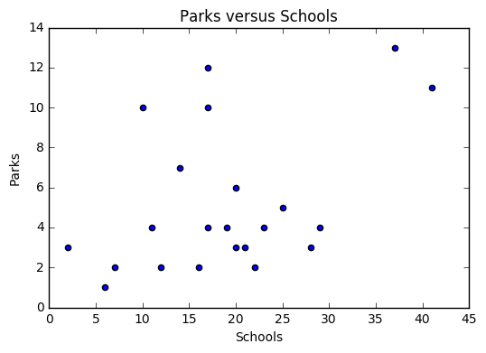

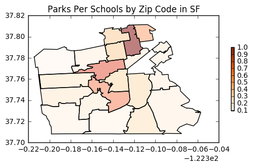

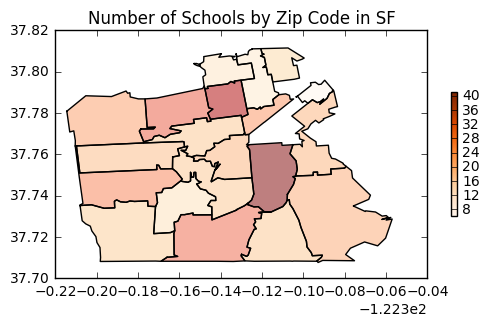

```python
schoolcount = pd.DataFrame(Counter(schoolzip).most_common(),columns = ['ZCTA5CE10','counts'])
parkcountdata.iloc[0,0]
zipma = []
for i in schoolcount['ZCTA5CE10']:
    zipma.append(int(i))
schoolcount['ZCTA5CE10'] = zipma

schoolcount['ZCTA5CE10']


schoolsandparks = schoolcount.merge(parkcountdata,on = 'ZCTA5CE10')
schoolsandparks.columns = ['ZCTA5CE10','Schools','Parks']
plotschool = schoolsandparks.plot.scatter('Schools','Parks',title = 'Parks versus Schools')
#plotschool.title = 'Parks versus Schools'
spplotdf = dfs.merge(schoolsandparks, on = 'ZCTA5CE10')
spplotdf['prkperschool'] = spplotdf['Parks']/spplotdf['Schools']
norm = Normalize()
cmap = plt.get_cmap('Oranges')
mapper = matplotlib.cm.ScalarMappable(norm=norm, cmap=cmap)
mapper.set_array(spplotdf['prkperschool'])
spplotdf.plot(column = 'prkperschool',cmap = 'OrRd',axes = None);
plt.title("Parks Per Schools by Zip Code in SF");
plt.colorbar(mapper, shrink=0.4);



norm = Normalize()
cmap = plt.get_cmap('Oranges')
mapper = matplotlib.cm.ScalarMappable(norm=norm, cmap=cmap)
mapper.set_array(spplotdf['Schools'])
spplotdf.plot(column = 'Schools',cmap = 'OrRd',axes = None);
plt.title("Number of Schools by Zip Code in SF");
plt.colorbar(mapper, shrink=0.4);
```

```python
spplotdf.iloc[:5,-5:]
```

|  | ZCTA5CE10 | geometry | Schools | Parks | prkperschool |
| --- | --- | --- | --- | --- | --- |
| 0 | 94122 | POLYGON ((-122.50987 37.76409, -122.508335 37.... | 19 | 4 | 0.210526 |
| 1 | 94110 | POLYGON ((-122.426722 37.736372, -122.425082 3... | 41 | 11 | 0.268293 |
| 2 | 94117 | POLYGON ((-122.477297 37.766069, -122.473124 3... | 17 | 12 | 0.705882 |
| 3 | 94107 | POLYGON ((-122.40509 37.76462799999999, -122.4... | 20 | 3 | 0.150000 |
| 4 | 94116 | POLYGON ((-122.510297 37.764073, -122.509833 3... | 25 | 5 | 0.200000 |

## Question 5

### Are Mobile Food Trucks Near Parks

For this problem I downloaded a shapefile from http://opendata.mtc.ca.gov/datasets/e8520a9b52c24d8ca2bd52586ed68e4b_12?uiTab=charts&selectedAttributes%5B%5D=CLASS&chartType=bar TO get a map of the BART and MUNI systems. I included the files as an attachment in the submission.

```python
subsetfood =  ourdfsql[(ourdfsql['Longitude'] < -100) & (ourdfsql['Latitude'] > 37)]
furthsub = subsetfood.drop_duplicates('Latitude')
```

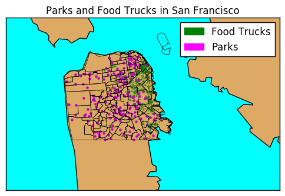

```python
sfigure = 'geo_export_74da5d7f-2883-4240-8d0d-f91d14b65588'

import matplotlib.patches as mpatches
map = Basemap(llcrnrlon=-122.6, llcrnrlat=37.65, urcrnrlon=-122.2, urcrnrlat=37.85, resolution="h",
    projection="merc")

map.readshapefile(sfigure,'sfigure')
map.drawmapboundary(fill_color='aqua')
map.fillcontinents(color='#ddaa66',zorder = 0)
map.drawcoastlines()
longy, laty = map(lons, lats)
map.scatter(longy, laty, marker='.',color='m')
lone, late = map(list(furthsub.Longitude),list(furthsub.Latitude))
map.scatter(lone,late,marker = '.',color = 'g',s = 1)
green_patch = mpatches.Patch(color='green', label='Food Trucks')
mag_patch = mpatches.Patch(color = 'magenta',label = 'Parks')

plt.legend(handles = [green_patch,mag_patch])
plt.title('Parks and Food Trucks in San Francisco')
plt.show()
```

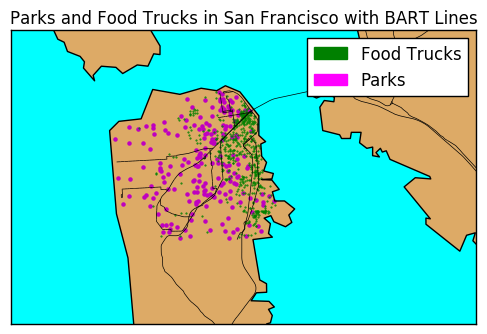

```python
sfrail = 'Passenger_Railways'

map = Basemap(llcrnrlon=-122.6, llcrnrlat=37.65, urcrnrlon=-122.2, urcrnrlat=37.85, resolution="h",
    projection="merc")

map.readshapefile(sfrail,'sfrail')
map.drawmapboundary(fill_color='aqua')
map.fillcontinents(color='#ddaa66',zorder = 0)
map.drawcoastlines()
longy, laty = map(lons, lats)
map.scatter(longy, laty, marker='.',color='m')
lone, late = map(list(furthsub.Longitude),list(furthsub.Latitude))
map.scatter(lone,late,marker = '.',color = 'g',s = 1)
green_patch = mpatches.Patch(color='green', label='Food Trucks')
mag_patch = mpatches.Patch(color = 'magenta',label = 'Parks')

plt.legend(handles = [green_patch,mag_patch])
plt.title('Parks and Food Trucks in San Francisco with BART Lines')
plt.show()
```

### Analysis

From the above plot we see that most of the food trucks are actually near the eastern part of San Francisco. It seems taht food trucks are less concerned with serving people in residential areas and at parks and more interested in selling at areas where there is large commerical interest. It's is also surpising to see the lack of food trucks in Fisherman's Wharf and the Marina where there is a lot of Tourist activity. From what this plot shows, the Financial district seems to be the primary area where food trucks are centered. This suggests that many people who go on lunch breaks throughout the day or get off work will visit food trucks. We also see from the public transit lines plot that many of the food trucks follow public transportation lines while parks will further extend west. While most of the Food Trucks are located in the financial district, the ones outside the commercial district do tend to be located near the parks.